# Predictive Text: Model Quality Review

Measured performance and remaining limitations

Sonja Sahebzad

2026-09-19

**Management summary.** The first predictor gave weak suggestions because rare contexts could dominate its ranking. The revised version combines longer and shorter contexts. On **1200** reserved test examples, its first suggestion is correct **13.0%** of the time, and one of its first three is correct **21.6%** of the time. The previous ranking rule scores **21.5%** on those same examples. This remains an experimental predictor; individual suggestions can be wrong.

# What changed and why

The earlier corpus search could stop at a short Twitter match, ignoring potentially better matches in the other files. A single occurrence could determine a suggestion. Percentages from different contexts were also presented together even though they did not form one probability distribution. Its separate perplexity calculation therefore did not evaluate the actual ranking method.

The revised **interpolated n-gram model** blends evidence from the last one, two and three words with overall word frequency [2]. Rare contexts receive less weight. The interactive script uses this same trained model and distribution as the evaluation. It shows the context used, supporting counts and a limited-evidence message when appropriate. It no longer scans the complete corpus for every query.

# Data and evaluation

The official English blogs, news and Twitter files [1] are read completely in chunks with UTF-8 encoding. Each line has a 2% sampling probability. Empty and duplicate normalized lines are removed before an approximately **80% training, 10% validation, 10% test** split within each source. Lowercasing and punctuation normalization retain internal apostrophes. Stopwords remain because they are useful next-word candidates.

Distinct sampled lines by source and partition

| source | test | train | validation |
| --- | --- | --- | --- |
| blogs | 1767 | 14250 | 1808 |
| news | 2081 | 16061 | 2024 |
| twitter | 4665 | 37215 | 4614 |

The validation and test sets each contain up to **400 examples per source**. One word position is selected randomly within each eligible line; only the preceding words are supplied to the predictor. This represents intermediate typing better than testing sentence endings alone. Equal source weights make the reported accuracy a balanced benchmark, rather than an estimate of a particular user’s writing habits. The test set is opened only after model selection.

# Candidate comparison

Validation results used to choose the model

| Method | Minimum count | Top-1 | Top-3 | Perplexity | Memory MiB |
| --- | --- | --- | --- | --- | --- |
| Word frequency only | 1 | 4.8% | 10.4% | 2,093.1 | 4.7 |
| Previous ranking rule | 2 | 14.2% | 23.5% | Not defined | 13.4 |
| Discounted interpolation | 1 | 13.0% | 22.8% | 829.8 | 173.1 |
| Discounted interpolation | 2 | 14.2% | 23.7% | 1,488.6 | 13.4 |
| Count-weighted interpolation | 1 | 12.4% | 22.1% | 1,006.6 | 173.1 |
| Count-weighted interpolation | 2 | 14.2% | 23.6% | 1,447.0 | 13.4 |

Two interpolation rules and minimum counts of one or two are compared with unigram and previous-ranking baselines. All candidates use the same training partition; the previous ranking rule is retrained for this comparison. The choice is **Discounted interpolation**, minimum count **2**. Among interpolation candidates within **0.5 percentage points** of the best validation top-3 accuracy, the smallest is selected. This is an explicit engineering trade-off, not a statistical equivalence test. No quiz answers enter training or selection.

# Results on the reserved test set

Both models tested on exactly the same unseen prefixes and targets

| Model | Top-1 | Top-2 | Top-3 | MRR | Perplexity |
| --- | --- | --- | --- | --- | --- |
| Previous ranking rule | 12.8% | 17.8% | 21.5% | 0.165 | Not defined |
| Discounted interpolation | 13.0% | 17.8% | 21.6% | 0.167 | 1,591.9 |

Top-3 accuracy means the recorded next word appears among the first three suggestions. Here that is **259 of 1200** examples. The difference from the previous ranking rule is **+0.1 percentage points**, with a paired bootstrap 95% interval of **-0.5 to +0.7 points**. The interval includes zero, so this test does not establish a reliable accuracy improvement. The selected model still misses **78.4%** of exact targets in its top three.

Performance differs across writing sources

| Source | Examples | Top-1 | Top-3 |
| --- | --- | --- | --- |
| blogs | 400 | 13.0% | 21.8% |
| news | 400 | 12.8% | 21.2% |
| twitter | 400 | 13.2% | 21.8% |

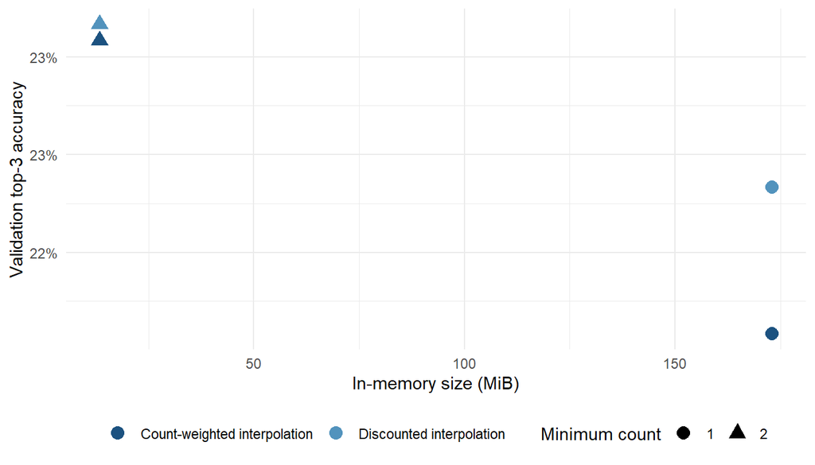

**Efficiency.** The selected model occupies **13.4 MiB** in memory. The median of three warmed evaluation runs is **6.02 ms per query**, including ranking and evaluation bookkeeping. This is local batch timing, not a guaranteed Shiny response time. The old corpus scan took about 27 seconds for one example; it was a different, unevaluated lookup procedure.

**Probability quality.** MRR rewards earlier correct suggestions. Perplexity uses the same full probability distribution as ranking, and lower values are better. It is measured at the sampled next-word positions, not over complete documents. Unseen target words map to one `<unk>` category for this calculation; **2.6%** of test targets are unseen, and count as misses for accuracy. The old ranking rule has no comparable normalized distribution, so its perplexity is not reported. Across the new candidates, ranking accuracy and perplexity must both be considered; a few validation settings cannot establish a general correlation.

# Discussion and conclusion

This revision fixes identifiable ranking and evaluation problems, but statistical word frequency cannot understand the meaning of an entire sentence. Rare phrases, names and source-specific language remain difficult. A different sensible next word is also scored as wrong when it differs from the single recorded target. The model uses at most three context words and can cross punctuation within a line; it has no semantic or topic model.

The results justify **continued development**, rather than a claim of reliable quiz answers or production readiness. Next steps are to compare larger training samples, test improved smoothing and sentence boundaries, add an output vocabulary filter, and measure app latency. The reserved test set should not be used repeatedly to tune those changes; a new final test would be needed.

# Reproducibility

This HTML was knitted from `12_predictive_model_evaluation.Rmd`. The source, evaluation CSVs and HTML are retained together in the RStudio project. `R/predictive_model_v2.R` contains model functions; `14_rebuild_prediction_v2.R` rebuilds counts, selects the configuration and evaluates it. `13_try_predictor.R` loads the selected model for interactive use.

| Item | Setting |
| --- | --- |
| Sampling and partition seed | 20260924 (+ source index); partitions +100 |
| Validation / test positions | 20261001 / 20261002 |
| Bootstrap seed | 20261003 |
| Vocabulary | 65614 training words plus one unknown-word category |
| Probability smoothing | Unigram additive 0.1; absolute discount 0.75 or count-weighted interpolation |
| Runtime | R 4.6.1 \| data.table 1.18.6.1 \| stringi 1.8.9 |

Input-file MD5 hashes, source-code hashes, partitions and session information are stored with the evaluation in `models/prediction_evaluation_v2.rds`. Model objects are rebuilt locally and excluded from Git. Re-knitting reads the saved measurements so timing values do not change unnecessarily.

```r
source("14_rebuild_prediction_v2.R")
rmarkdown::render("12_predictive_model_evaluation.Rmd")
source("13_try_predictor.R")
```

The console also accepts optional comma-separated answer choices. It ranks those supplied words with the same distribution. This is a constrained comparison, not evidence that any option is correct; the benchmark above measures unrestricted next-word prediction.

# References

1. Coursera and SwiftKey. *Data Science Capstone corpus*. [Official data](https://d396qusza40orc.cloudfront.net/dsscapstone/dataset/Coursera-SwiftKey.zip).
2. Jurafsky, D., and Martin, J. H. (2026 draft). *Speech and Language Processing*, Chapter 3: N-gram Language Models. [Stanford chapter](https://web.stanford.edu/~jurafsky/slp3/3.pdf).
3. data.table authors. *Enhanced data.frame and keyed joins*. [Package documentation](https://rdatatable.gitlab.io/data.table/reference/data.table.html).
4. stringi authors. *Character string processing facilities*. [Package documentation](https://stringi.gagolewski.com/).